# Homework 8

Applied Predictive Modeling - Non Linear Regression Models

Paul Perez

4/25/2021

```r
library(tidyverse)
library(e1071)
library(forecast)
library(AppliedPredictiveModeling)
library(mlbench)
library(nnet)
library(neural)
library(RSNNS)
```

```r
library(plotmo)
library(caret)
```

# Exercise 7.2

Friedman (1991) introduced several benchmark data sets create by simulation. One of these simulations used the following nonlinear equation to create data:

$$y = 10 sin (\pi x_1 x_2) + 20(x_3−0.5)^2 + 10x_4 +5x_5 + N(0,\sigma^2)$$

where the x values are random variables uniformly distributed between [0, 1] (there are also 5 other non-informative variables also created in the simulation). The package mlbench contains a function called `mlbench.friedman1` that simulates these data:

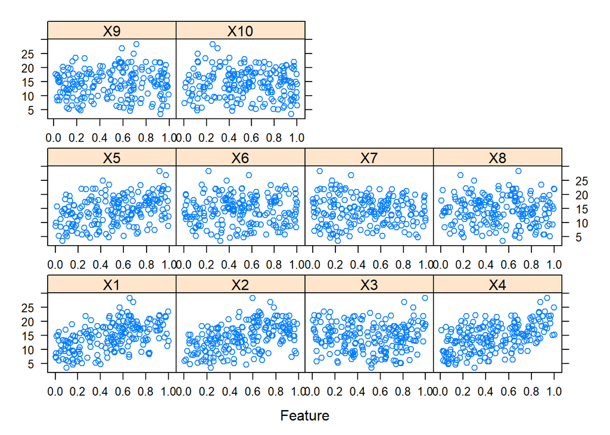

```r
library(mlbench)
set.seed(200)
trainingData <- mlbench.friedman1(200, sd = 1)
## We convert the 'x' data from a matrix to a data frame
## One reason is that this will five the columns names.
trainingData$x <- data.frame(trainingData$x)
## Look at the data using
featurePlot(trainingData$x, trainingData$y)
```

```r
## or other methods.

## This creates a list with a vector 'y' and a matrix
## of predictors 'x'.  Also simulate a large test set to
## estimate the true error rate with good precision:
testData <- mlbench.friedman1(5000, sd = 1)
testData$x <- data.frame(testData$x)
```

### KNN

```r
require(caret)
knnModel <- train(x = trainingData$x,
                  y = trainingData$y,
                  method = "knn",
                  preProcess = c("center", "scale"),
                  tuneLength = 10)
knnModel
```

```
## k-Nearest Neighbors
##
## 200 samples
##  10 predictor
##
## Pre-processing: centered (10), scaled (10)
## Resampling: Bootstrapped (25 reps)
## Summary of sample sizes: 200, 200, 200, 200, 200, 200, ...
## Resampling results across tuning parameters:
##
##   k   RMSE      Rsquared   MAE
##    5  3.466085  0.5121775  2.816838
##    7  3.349428  0.5452823  2.727410
##    9  3.264276  0.5785990  2.660026
##   11  3.214216  0.6024244  2.603767
##   13  3.196510  0.6176570  2.591935
##   15  3.184173  0.6305506  2.577482
##   17  3.183130  0.6425367  2.567787
##   19  3.198752  0.6483184  2.592683
##   21  3.188993  0.6611428  2.588787
##   23  3.200458  0.6638353  2.604529
##
## RMSE was used to select the optimal model using the smallest value.
## The final value used for the model was k = 17.
```

```r
knnPred <- predict(knnModel, newdata = testData$x)
## The function 'postResample' can be used to get the test set
## performance values
postResample(pred = knnPred, obs = testData$y)
```

```
##      RMSE  Rsquared       MAE
## 3.2040595 0.6819919 2.5683461
```

```r
knnModel$bestTune
```

```
##    k
## 7 17
```

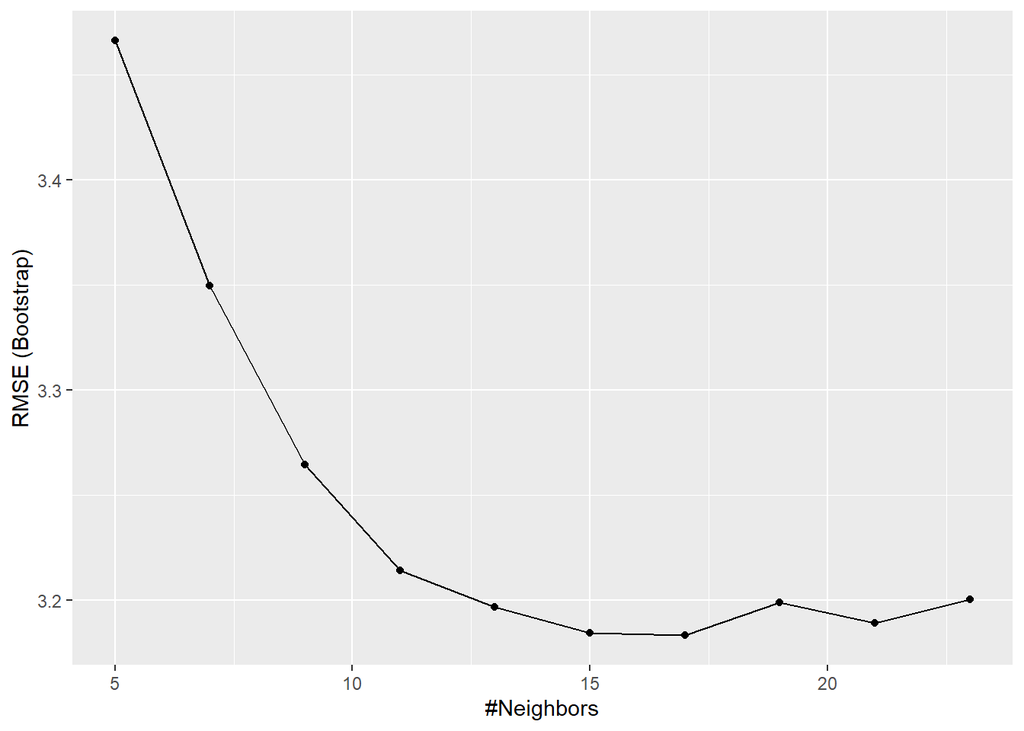

```r
ggplot(knnModel)
```

```r
knnModel$finalModel
```

```
## 17-nearest neighbor regression model
```

```r
varImp(knnModel)
```

```
## loess r-squared variable importance
##
##      Overall
## X4  100.0000
## X1   95.5047
## X2   89.6186
## X5   45.2170
## X3   29.9330
## X9    6.3299
## X10   5.5182
## X8    3.2527
## X6    0.8884
## X7    0.0000
```

```r
plot(varImp(knnModel))
```

We see 9 important variables with the Knn model.

### MARS

```r
library(plotmo)
marsGrid <- expand.grid(.degree = 1:2, .nprune = 2:38)
# Fix the seed tso that the results can be reproduced
set.seed(123)
marsTuned <- train(x = trainingData$x,
                  y = trainingData$y,
                  method = "earth",
                  tuneGrid = marsGrid,
                  preProcess = c("center", "scale"),
                  tuneLength = 10)
marsTuned
```

```
## Multivariate Adaptive Regression Spline
##
## 200 samples
##  10 predictor
##
## Pre-processing: centered (10), scaled (10)
## Resampling: Bootstrapped (25 reps)
## Summary of sample sizes: 200, 200, 200, 200, 200, 200, ...
## Resampling results across tuning parameters:
##
##   degree  nprune  RMSE      Rsquared   MAE
##   1        2      4.379381  0.2301740  3.575902
##   1        3      3.649438  0.4583683  2.944879
##   1        4      2.769352  0.6876944  2.223704
##   1        5      2.529007  0.7399204  2.018331
```

[output cut: 73 more lines]

```r
marsTuned$bestTune
```

```
##    nprune degree
## 50     14      2
```

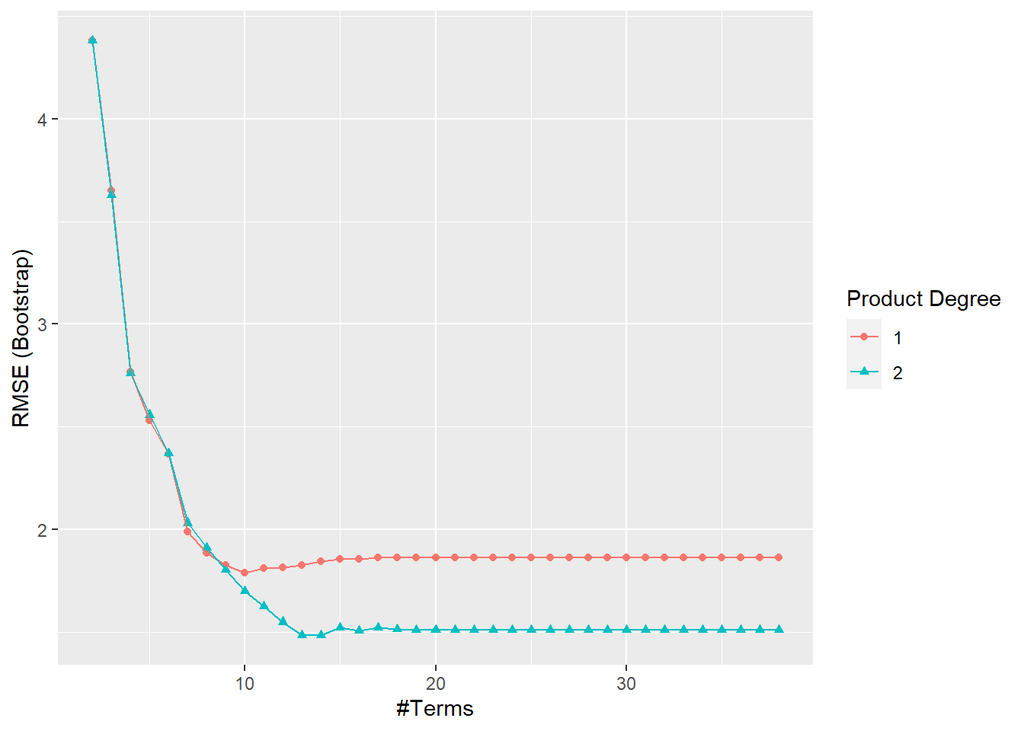

```r
ggplot(marsTuned)
```

```r
marsTuned$finalModel
```

```
## Selected 14 of 21 terms, and 5 of 10 predictors (nprune=14)
## Termination condition: Reached nk 21
## Importance: X1, X4, X2, X5, X3, X6-unused, X7-unused, X8-unused, X9-unused, ...
## Number of terms at each degree of interaction: 1 8 5
## GCV 1.841667    RSS 255.2757    GRSq 0.9252276    RSq 0.9476564
```

```r
varImp(marsTuned)
```

```
## earth variable importance
##
##    Overall
## X1  100.00
## X4   75.40
## X2   49.00
## X5   15.72
## X3    0.00
```

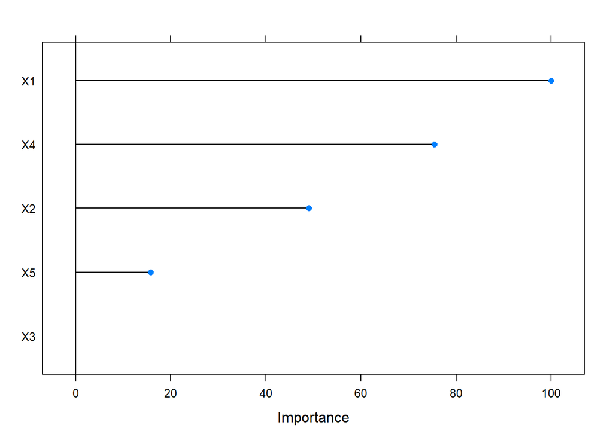

```r
plot(varImp(marsTuned))
```

We can see that with the Mars Model, there is are 5 variables of importance.

### Neural Networks

```r
## Create a specific candidate set of models to evaluate:
nnetGrid <- expand.grid(decay = c(0, 0.01, .1), size = c(1:10), bag = FALSE)
set.seed(123)
nnetTuned <- train(trainingData$x, trainingData$y,
                  method = "avNNet",
                  tuneGrid = nnetGrid,
                  trControl = trainControl(method = "cv", number = 10),
                  preProc = c("center", "scale"),
                  linout = TRUE,  trace = FALSE,
                  MaxNWts = 10 * (ncol(trainingData$x) + 1) + 10 + 1,
                  maxit = 500)
nnetTuned
```

```
## Model Averaged Neural Network
##
## 200 samples
##  10 predictor
##
## Pre-processing: centered (10), scaled (10)
## Resampling: Cross-Validated (10 fold)
## Summary of sample sizes: 180, 180, 180, 180, 180, 180, ...
## Resampling results across tuning parameters:
##
##   decay  size  RMSE      Rsquared   MAE
##   0.00    1    2.452180  0.7599331  1.930928
##   0.00    2    2.485152  0.7541137  1.927017
##   0.00    3    2.185856  0.8109791  1.681071
##   0.00    4    1.993571  0.8407723  1.551487
##   0.00    5    2.701977  0.7617054  1.943622
##   0.00    6    2.925647  0.6854636  2.107987
##   0.00    7    3.451341  0.6284836  2.334662
##   0.00    8    3.480111  0.6495042  2.439548
##   0.00    9    4.291654  0.5374468  2.815243
##   0.00   10    3.184263  0.6185828  2.408581
##   0.01    1    2.428309  0.7650810  1.880485
##   0.01    2    2.474197  0.7522591  1.932316
##   0.01    3    2.096876  0.8243742  1.655013
##   0.01    4    2.059841  0.8255968  1.570884
##   0.01    5    2.137708  0.8140916  1.688930
##   0.01    6    2.231237  0.8046076  1.764388
##   0.01    7    2.409379  0.7703673  1.817734
##   0.01    8    2.424670  0.7673145  1.957841
##   0.01    9    2.364414  0.7868413  1.878362
##   0.01   10    2.492444  0.7514049  1.950227
##   0.10    1    2.441801  0.7622380  1.891949
##   0.10    2    2.454704  0.7594003  1.897313
##   0.10    3    2.095422  0.8228519  1.616598
##   0.10    4    2.029611  0.8353959  1.594489
##   0.10    5    2.100685  0.8242507  1.647470
##   0.10    6    2.248341  0.7918856  1.744779
##   0.10    7    2.280620  0.7864106  1.784696
##   0.10    8    2.250522  0.7942895  1.795268
##   0.10    9    2.187986  0.8023063  1.725691
##   0.10   10    2.306080  0.7891805  1.824779
##
## Tuning parameter 'bag' was held constant at a value of FALSE
## RMSE was used to select the optimal model using the smallest value.
## The final values used for the model were size = 4, decay = 0 and bag = FALSE.
```

```r
nnetTuned$bestTune
```

```
##   size decay   bag
## 4    4     0 FALSE
```

```r
nnetTuned$finalModel
```

```
## Model Averaged Neural Network with 5 Repeats
##
## a 10-4-1 network with 49 weights
## options were - linear output units
```

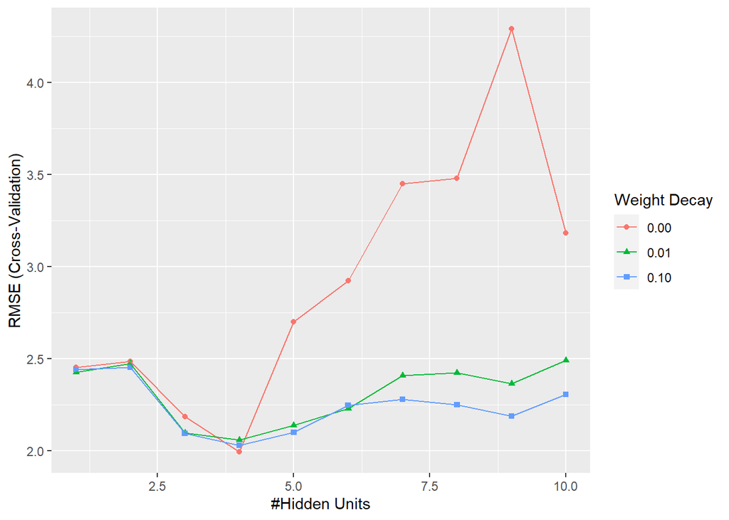

```r
ggplot(nnetTuned)
```

```r
varImp(nnetTuned)
```

```
## loess r-squared variable importance
##
##      Overall
## X4  100.0000
## X1   95.5047
## X2   89.6186
## X5   45.2170
## X3   29.9330
## X9    6.3299
## X10   5.5182
## X8    3.2527
## X6    0.8884
## X7    0.0000
```

```r
plot(varImp(nnetTuned))
```

With the neural network model, we see that there are 9 variables of importance.

### Support Vector Machines

```r
set.seed(123)
svmTuned <- train(trainingData$x, trainingData$y,
                     method = "svmRadial",
                     preProc = c("center", "scale"),
                     tuneLength = 14,
                     trControl = trainControl(method = "cv"))
svmTuned
```

```
## Support Vector Machines with Radial Basis Function Kernel
##
## 200 samples
##  10 predictor
##
## Pre-processing: centered (10), scaled (10)
## Resampling: Cross-Validated (10 fold)
## Summary of sample sizes: 180, 180, 180, 180, 180, 180, ...
## Resampling results across tuning parameters:
##
##   C        RMSE      Rsquared   MAE
##      0.25  2.525164  0.7989116  1.998994
##      0.50  2.271713  0.8133084  1.790740
##      1.00  2.064043  0.8412920  1.624067
##      2.00  1.976789  0.8514492  1.552993
##      4.00  1.886800  0.8637795  1.487584
##      8.00  1.855491  0.8685704  1.470043
##     16.00  1.857543  0.8685349  1.476922
##     32.00  1.857534  0.8685369  1.476921
##     64.00  1.857534  0.8685369  1.476921
##    128.00  1.857534  0.8685369  1.476921
##    256.00  1.857534  0.8685369  1.476921
##    512.00  1.857534  0.8685369  1.476921
##   1024.00  1.857534  0.8685369  1.476921
##   2048.00  1.857534  0.8685369  1.476921
##
## Tuning parameter 'sigma' was held constant at a value of 0.06510592
## RMSE was used to select the optimal model using the smallest value.
## The final values used for the model were sigma = 0.06510592 and C = 8.
```

```r
svmTuned$bestTune
```

```
##        sigma C
## 6 0.06510592 8
```

```r
svmTuned$finalModel
```

```
## Support Vector Machine object of class "ksvm"
##
## SV type: eps-svr  (regression)
##  parameter : epsilon = 0.1  cost C = 8
##
## Gaussian Radial Basis kernel function.
##  Hyperparameter : sigma =  0.0651059217682105
##
## Number of Support Vectors : 152
##
## Objective Function Value : -69.5625
## Training error : 0.009013
```

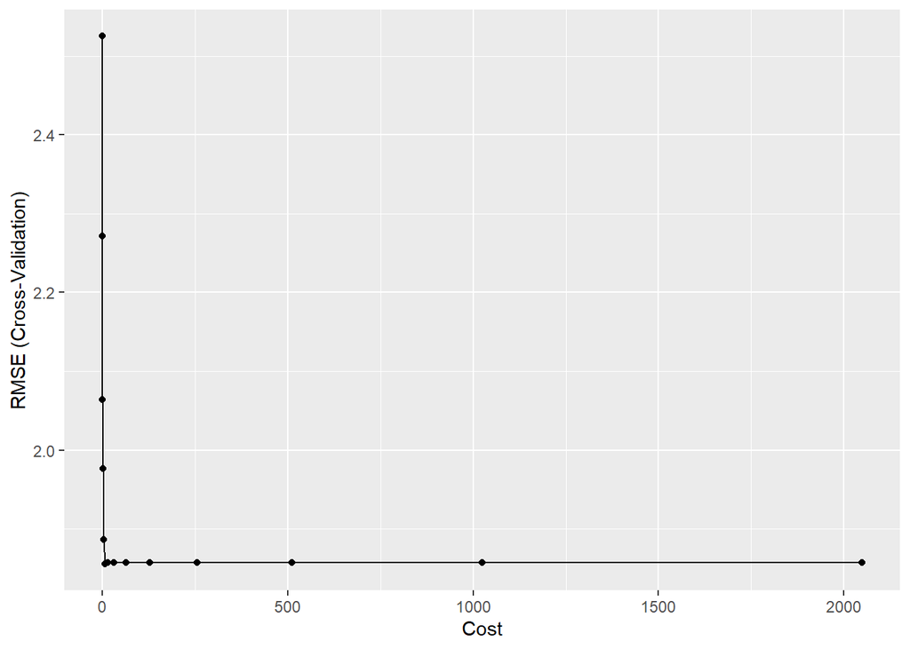

```r
ggplot(svmTuned)
```

```r
varImp(svmTuned)
```

```
## loess r-squared variable importance
##
##      Overall
## X4  100.0000
## X1   95.5047
## X2   89.6186
## X5   45.2170
## X3   29.9330
## X9    6.3299
## X10   5.5182
## X8    3.2527
## X6    0.8884
## X7    0.0000
```

```r
plot(varImp(svmTuned))
```

With out support vector model, we see there are 9 variables of importance.

#### Comparison of Models

```r
marsPred <- predict(marsTuned, newdata = testData$x)
marsPv <- postResample(pred = marsPred, obs = testData$y)
marsPv
```

```
##      RMSE  Rsquared       MAE
## 1.2779993 0.9338365 1.0147070
```

```r
nnPred <- predict(nnetTuned, newdata = testData$x)
nnPv <- postResample(pred = nnPred, obs = testData$y)
nnPv
```

```
##      RMSE  Rsquared       MAE
## 4.8713326 0.4855538 2.2546388
```

```r
svmPred <- predict(svmTuned, newdata = testData$x)
svmPv <- postResample(pred = svmPred, obs = testData$y)
svmPv
```

```
##      RMSE  Rsquared       MAE
## 2.0634091 0.8275351 1.5663529
```

```r
knnPred <- predict(knnModel, newdata = testData$x)
knnPv <- postResample(pred = knnPred, obs = testData$y)
knnPv
```

```
##      RMSE  Rsquared       MAE
## 3.2040595 0.6819919 2.5683461
```

We can see that with our models, the MARS model presents the greatest r-Squared and lowest RMSE. Looking at the variables of importance for the MARS model, we see those variables named X1 - X5.

# Exercise 7.5

Exercise 6.3 describes data for a chemical manufacturing process. Use the same data imputation, data splitting, and pre-processing steps as before and train several nonlinear regression models.

For week 10’s homework. I created a ridge regression model. Below is the code. Following that, are the non-linear models for this exercise.

### (a) Which nonlinear regression model gives the optimal resampling and test set performance?

```r
library(RANN)
data("ChemicalManufacturingProcess")
preprocessing <- preProcess(ChemicalManufacturingProcess[,-1],
                            method = c("center", "scale", "knnImpute", "corr", "nzv"))
preprocess <- predict(preprocessing, ChemicalManufacturingProcess[,-1])
```

```r
yield <- as.matrix(ChemicalManufacturingProcess$Yield)
set.seed(123)
split2 <- createDataPartition(yield, p = 0.8, list = FALSE, times = 1)

Xtrain.data2  <- preprocess[split2, ]
xtest.data2 <- preprocess[-split2, ]
Ytrain.data2  <- yield[split2, ]
ytest.data2 <- yield[-split2, ]
```

```r
ridge.grid <- data.frame(.lambda = seq(0, .1, length = 15))
set.seed(123)
ctrl <- trainControl(method = "cv", number = 10)
ridge.mod2 <- train(x=Xtrain.data2,
                    y=Ytrain.data2,
                    method="ridge",
                    tuneGrid=ridge.grid,
                    trControl= ctrl)
ridge.mod2
```

```
## Ridge Regression
##
## 144 samples
##  56 predictor
##
## No pre-processing
## Resampling: Cross-Validated (10 fold)
## Summary of sample sizes: 128, 129, 129, 130, 128, 131, ...
## Resampling results across tuning parameters:
##
##   lambda       RMSE      Rsquared   MAE
##   0.000000000  8.231140  0.5001829  3.365686
##   0.007142857  5.177328  0.4945675  2.430293
##   0.014285714  4.329076  0.5069033  2.138368
##   0.021428571  3.853764  0.5158292  1.977340
##   0.028571429  3.533281  0.5225199  1.872177
##   0.035714286  3.296381  0.5278183  1.792915
##   0.042857143  3.111303  0.5321913  1.729989
##   0.050000000  2.961284  0.5359104  1.678308
##   0.057142857  2.836451  0.5391442  1.634722
##   0.064285714  2.730522  0.5420033  1.597395
##   0.071428571  2.639265  0.5445641  1.565126
##   0.078571429  2.559696  0.5468811  1.536722
##   0.085714286  2.489636  0.5489948  1.511494
##   0.092857143  2.427447  0.5509361  1.488916
##   0.100000000  2.371869  0.5527288  1.468582
##
## RMSE was used to select the optimal model using the smallest value.
## The final value used for the model was lambda = 0.1.
```

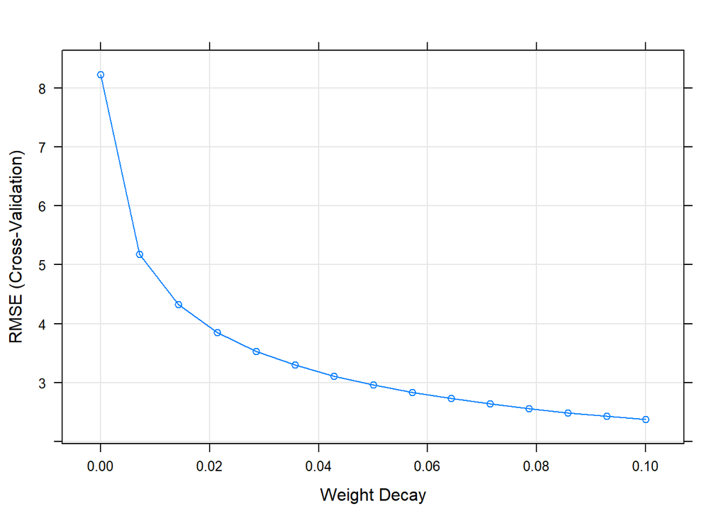

```r
plot(ridge.mod2)
```

```r
ridge.mod2$bestTune
```

```
##    lambda
## 15    0.1
```

```r
ridge.mod2$finalModel
```

```
##
## Call:
## elasticnet::enet(x = as.matrix(x), y = y, lambda = param$lambda)
## Sequence of  moves:
##      ManufacturingProcess32 ManufacturingProcess09 BiologicalMaterial06
## Var                      43                     20                    6
## Step                      1                      2                    3
##      ManufacturingProcess13 ManufacturingProcess17 ManufacturingProcess36
## Var                      24                     28                     47
## Step                      4                      5                      6
##      ManufacturingProcess06 ManufacturingProcess37 ManufacturingProcess44
## Var                      17                     48                     55
## Step                      7                      8                      9
##      ManufacturingProcess11 ManufacturingProcess45 ManufacturingProcess39
## Var                      22                     56                     50
## Step                     10                     11                     12
##      ManufacturingProcess15 BiologicalMaterial05 ManufacturingProcess34
## Var                      26                    5                     45
## Step                     13                   14                     15
##      BiologicalMaterial03 ManufacturingProcess43 ManufacturingProcess30
## Var                     3                     54                     41
## Step                   16                     17                     18
##      ManufacturingProcess11 ManufacturingProcess04 BiologicalMaterial09
## Var                     -22                     15                    8
## Step                     19                     20                   21
##      ManufacturingProcess07 ManufacturingProcess28 ManufacturingProcess18
## Var                      18                     39                     29
## Step                     22                     23                     24
##      ManufacturingProcess42 ManufacturingProcess19 ManufacturingProcess41
## Var                      53                     30                     52
## Step                     25                     26                     27
##      ManufacturingProcess08 ManufacturingProcess24 ManufacturingProcess29
## Var                      19                     35                     40
## Step                     28                     29                     30
##      ManufacturingProcess01 ManufacturingProcess11 BiologicalMaterial02
## Var                      12                     22                    2
## Step                     31                     32                   33
##      BiologicalMaterial10 ManufacturingProcess12 ManufacturingProcess38
## Var                     9                     23                     49
## Step                   34                     35                     36
```

[output cut: 9 more lines]

```
##      ManufacturingProcess35 ManufacturingProcess05 BiologicalMaterial08
## Var                      46                     16                    7
## Step                     46                     47                   48
##      ManufacturingProcess14 ManufacturingProcess27 ManufacturingProcess33
## Var                      25                     38                     44
## Step                     49                     50                     51
##      ManufacturingProcess25 ManufacturingProcess40 ManufacturingProcess10
## Var                      36                     51                     21
## Step                     52                     53                     54
##      ManufacturingProcess30 ManufacturingProcess31 BiologicalMaterial04
## Var                      41                     42                    4
## Step                     55                     56                   57
##      ManufacturingProcess22 ManufacturingProcess26 BiologicalMaterial12
## Var                      33                     37                   11 61
## Step                     58                     59                   60 61
```

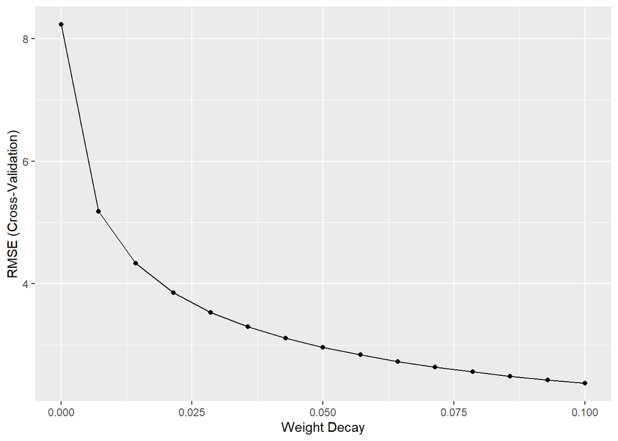

```r
ggplot(ridge.mod2)
```

```r
varImp(ridge.mod2)
```

```
## loess r-squared variable importance
##
##   only 20 most important variables shown (out of 56)
##
##                        Overall
## ManufacturingProcess32  100.00
## BiologicalMaterial06     94.06
## BiologicalMaterial03     81.27
## ManufacturingProcess13   80.63
## ManufacturingProcess36   78.46
## BiologicalMaterial02     76.04
## ManufacturingProcess17   75.92
## ManufacturingProcess31   75.30
## ManufacturingProcess09   73.04
## BiologicalMaterial12     69.48
## ManufacturingProcess06   66.28
## BiologicalMaterial11     59.72
## ManufacturingProcess33   58.31
## ManufacturingProcess29   54.48
## BiologicalMaterial04     53.93
## ManufacturingProcess11   47.22
## BiologicalMaterial01     45.62
## BiologicalMaterial08     44.93
## BiologicalMaterial09     40.88
## ManufacturingProcess30   40.40
```

```r
plot(varImp(ridge.mod2))
```

### MARS

```r
marsGrid <- expand.grid(.degree = 1:3, .nprune = 2:100)
set.seed(123)
chemMarsTuned <- train(Xtrain.data2, Ytrain.data2,
                   method = "earth",
                   tuneGrid = marsGrid,
                   trControl = trainControl(method = "cv", number = 10))
chemMarsTuned
```

```
## Multivariate Adaptive Regression Spline
##
## 144 samples
##  56 predictor
##
## No pre-processing
## Resampling: Cross-Validated (10 fold)
## Summary of sample sizes: 128, 129, 129, 130, 128, 131, ...
## Resampling results across tuning parameters:
##
##   degree  nprune  RMSE      Rsquared   MAE
##   1         2     1.378691  0.4988104  1.1236683
##   1         3     1.229449  0.6256651  0.9980716
##   1         4     1.242893  0.5988644  1.0087761
##   1         5     1.294698  0.5556355  1.0582204
```

[output cut: 296 more lines]

```r
chemMarsTuned$bestTune
```

```
##   nprune degree
## 2      3      1
```

```r
chemMarsTuned$finalModel
```

```
## Selected 3 of 27 terms, and 2 of 56 predictors (nprune=3)
## Termination condition: RSq changed by less than 0.001 at 27 terms
## Importance: ManufacturingProcess32, ManufacturingProcess17, ...
## Number of terms at each degree of interaction: 1 2 (additive model)
## GCV 1.616459    RSS 216.8862    GRSq 0.5318568    RSq 0.5576803
```

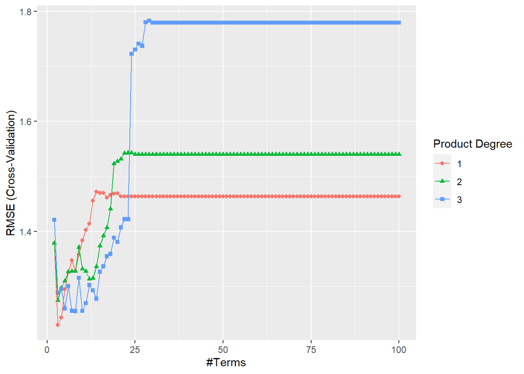

```r
ggplot(chemMarsTuned)
```

```r
varImp(chemMarsTuned)
```

```
## earth variable importance
##
##                        Overall
## ManufacturingProcess32     100
## ManufacturingProcess17       0
```

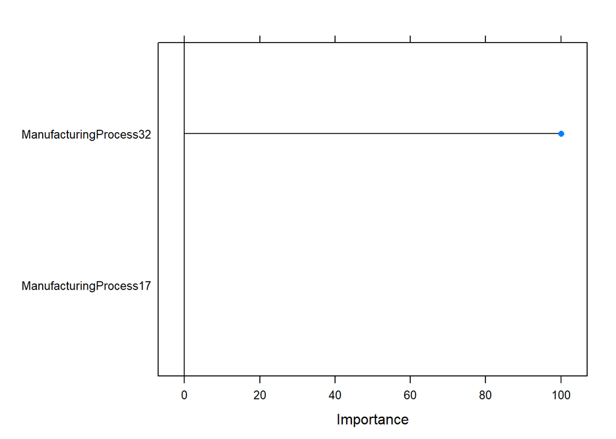

```r
plot(varImp(chemMarsTuned))
```

### Support Vector Machine

```r
set.seed(123)
chemSvmTuned <- train(Xtrain.data2, Ytrain.data2,
                     method = "svmRadial",
                     preProc = c("center", "scale"),
                     tuneLength = 14,
                     trControl = trainControl(method = "cv"))
chemSvmTuned
```

```
## Support Vector Machines with Radial Basis Function Kernel
##
## 144 samples
##  56 predictor
##
## Pre-processing: centered (56), scaled (56)
## Resampling: Cross-Validated (10 fold)
## Summary of sample sizes: 128, 129, 129, 130, 128, 131, ...
## Resampling results across tuning parameters:
##
##   C        RMSE      Rsquared   MAE
##      0.25  1.358199  0.5690883  1.1072819
##      0.50  1.261088  0.6004253  1.0283375
##      1.00  1.164762  0.6445964  0.9420864
##      2.00  1.110520  0.6664227  0.8972324
##      4.00  1.098859  0.6647994  0.8753518
##      8.00  1.079972  0.6806794  0.8572447
##     16.00  1.077640  0.6832634  0.8562086
##     32.00  1.077640  0.6832634  0.8562086
##     64.00  1.077640  0.6832634  0.8562086
##    128.00  1.077640  0.6832634  0.8562086
##    256.00  1.077640  0.6832634  0.8562086
##    512.00  1.077640  0.6832634  0.8562086
##   1024.00  1.077640  0.6832634  0.8562086
##   2048.00  1.077640  0.6832634  0.8562086
##
## Tuning parameter 'sigma' was held constant at a value of 0.01459873
## RMSE was used to select the optimal model using the smallest value.
## The final values used for the model were sigma = 0.01459873 and C = 16.
```

```r
chemSvmTuned$bestTune
```

```
##        sigma  C
## 7 0.01459873 16
```

```r
chemSvmTuned$finalModel
```

```
## Support Vector Machine object of class "ksvm"
##
## SV type: eps-svr  (regression)
##  parameter : epsilon = 0.1  cost C = 16
##
## Gaussian Radial Basis kernel function.
##  Hyperparameter : sigma =  0.0145987331756876
##
## Number of Support Vectors : 127
##
## Objective Function Value : -85.9221
## Training error : 0.009218
```

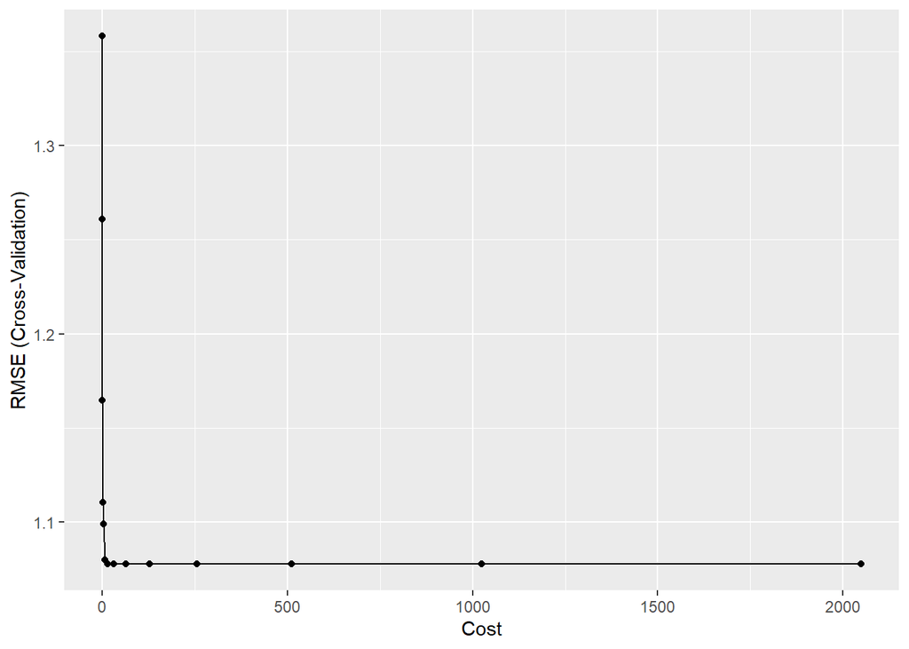

```r
ggplot(chemSvmTuned)
```

```r
varImp(chemSvmTuned)
```

```
## loess r-squared variable importance
##
##   only 20 most important variables shown (out of 56)
##
##                        Overall
## ManufacturingProcess32  100.00
## BiologicalMaterial06     94.06
## BiologicalMaterial03     81.27
## ManufacturingProcess13   80.63
## ManufacturingProcess36   78.46
## BiologicalMaterial02     76.04
## ManufacturingProcess17   75.92
## ManufacturingProcess31   75.30
## ManufacturingProcess09   73.04
## BiologicalMaterial12     69.48
## ManufacturingProcess06   66.28
## BiologicalMaterial11     59.72
## ManufacturingProcess33   58.31
## ManufacturingProcess29   54.48
## BiologicalMaterial04     53.93
## ManufacturingProcess11   47.22
## BiologicalMaterial01     45.62
## BiologicalMaterial08     44.93
## BiologicalMaterial09     40.88
## ManufacturingProcess30   40.40
```

```r
plot(varImp(chemSvmTuned))
```

### KNN

```r
set.seed(123)
chemKnnTuned <- train(Xtrain.data2,
                        Ytrain.data2,
                        method = "knn",
                        tuneGrid = data.frame(.k = 1:20),
                        trControl = trainControl(method = "cv"))
chemKnnTuned
```

```
## k-Nearest Neighbors
##
## 144 samples
##  56 predictor
##
## No pre-processing
## Resampling: Cross-Validated (10 fold)
## Summary of sample sizes: 128, 129, 129, 130, 128, 131, ...
## Resampling results across tuning parameters:
##
##   k   RMSE      Rsquared   MAE
##    1  1.358060  0.4758038  1.0044919
##    2  1.260411  0.5513114  1.0279356
##    3  1.183154  0.6186703  0.9477353
##    4  1.196262  0.6205875  0.9401482
##    5  1.265623  0.5679099  1.0218853
##    6  1.292113  0.5499524  1.0423154
##    7  1.302625  0.5493849  1.0694261
##    8  1.306568  0.5481933  1.0746831
##    9  1.320607  0.5340769  1.0827589
##   10  1.319865  0.5293304  1.0720121
##   11  1.320588  0.5253325  1.0716907
##   12  1.324967  0.5246326  1.0705794
##   13  1.334184  0.5159534  1.0831507
##   14  1.330196  0.5177505  1.0813916
##   15  1.351561  0.5061770  1.0995404
##   16  1.356930  0.5046626  1.1051983
##   17  1.359162  0.5075595  1.1035367
##   18  1.355510  0.5105725  1.1044369
##   19  1.375755  0.4928124  1.1158865
##   20  1.381201  0.4914472  1.1196329
##
## RMSE was used to select the optimal model using the smallest value.
## The final value used for the model was k = 3.
```

```r
chemKnnTuned$bestTune
```

```
##   k
## 3 3
```

```r
chemKnnTuned$finalModel
```

```
## 3-nearest neighbor regression model
```

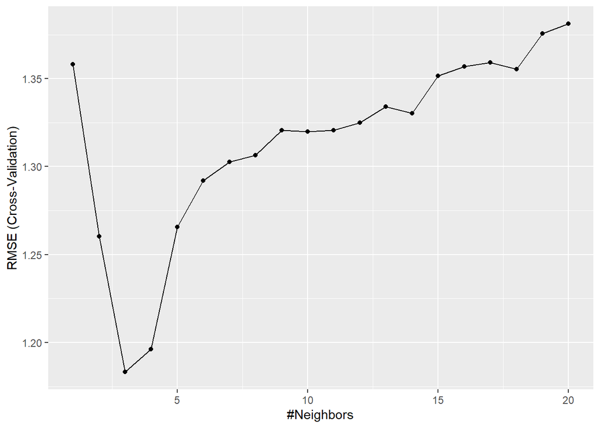

```r
ggplot(chemKnnTuned)
```

```r
varImp(chemKnnTuned)
```

```
## loess r-squared variable importance
##
##   only 20 most important variables shown (out of 56)
##
##                        Overall
## ManufacturingProcess32  100.00
## BiologicalMaterial06     94.06
## BiologicalMaterial03     81.27
## ManufacturingProcess13   80.63
## ManufacturingProcess36   78.46
## BiologicalMaterial02     76.04
## ManufacturingProcess17   75.92
## ManufacturingProcess31   75.30
## ManufacturingProcess09   73.04
## BiologicalMaterial12     69.48
## ManufacturingProcess06   66.28
## BiologicalMaterial11     59.72
## ManufacturingProcess33   58.31
## ManufacturingProcess29   54.48
## BiologicalMaterial04     53.93
## ManufacturingProcess11   47.22
## BiologicalMaterial01     45.62
## BiologicalMaterial08     44.93
## BiologicalMaterial09     40.88
## ManufacturingProcess30   40.40
```

```r
plot(varImp(chemKnnTuned))
```

#### Comparison of Models

```r
ridgePred <- predict(ridge.mod2, newdata = xtest.data2)
ridgePv2 <- postResample(pred = ridgePred, obs = ytest.data2)
ridgePv2
```

```
##      RMSE  Rsquared       MAE
## 1.3853397 0.4873811 1.1991549
```

```r
marsPred2 <- predict(chemMarsTuned, newdata = xtest.data2)
marsPv2 <- postResample(pred = marsPred2, obs = ytest.data2)
marsPv2
```

```
##      RMSE  Rsquared       MAE
## 1.1912611 0.5923659 0.9412672
```

```r
svmPred2 <- predict(chemSvmTuned, newdata = xtest.data2)
svmPv2 <- postResample(pred = svmPred2, obs = ytest.data2)
svmPv2
```

```
##     RMSE Rsquared      MAE
## 1.230302 0.549884 1.035976
```

```r
knnPred2 <- predict(chemKnnTuned, newdata = xtest.data2)
knnPv2 <- postResample(pred = knnPred2, obs = ytest.data2)
knnPv2
```

```
##      RMSE  Rsquared       MAE
## 1.4664201 0.3602785 1.1282292
```

### (b) Which predictors are most important in the optimal nonlinear regression model?

```r
varImp(chemSvmTuned)
```

```
## loess r-squared variable importance
##
##   only 20 most important variables shown (out of 56)
##
##                        Overall
## ManufacturingProcess32  100.00
## BiologicalMaterial06     94.06
## BiologicalMaterial03     81.27
## ManufacturingProcess13   80.63
## ManufacturingProcess36   78.46
## BiologicalMaterial02     76.04
## ManufacturingProcess17   75.92
## ManufacturingProcess31   75.30
## ManufacturingProcess09   73.04
## BiologicalMaterial12     69.48
## ManufacturingProcess06   66.28
## BiologicalMaterial11     59.72
## ManufacturingProcess33   58.31
## ManufacturingProcess29   54.48
## BiologicalMaterial04     53.93
## ManufacturingProcess11   47.22
## BiologicalMaterial01     45.62
## BiologicalMaterial08     44.93
## BiologicalMaterial09     40.88
## ManufacturingProcess30   40.40
```

### Ridge

```r
varImp(ridge.mod2)
```

```
## loess r-squared variable importance
##
##   only 20 most important variables shown (out of 56)
##
##                        Overall
## ManufacturingProcess32  100.00
## BiologicalMaterial06     94.06
## BiologicalMaterial03     81.27
## ManufacturingProcess13   80.63
## ManufacturingProcess36   78.46
## BiologicalMaterial02     76.04
## ManufacturingProcess17   75.92
## ManufacturingProcess31   75.30
## ManufacturingProcess09   73.04
## BiologicalMaterial12     69.48
## ManufacturingProcess06   66.28
## BiologicalMaterial11     59.72
## ManufacturingProcess33   58.31
## ManufacturingProcess29   54.48
## BiologicalMaterial04     53.93
## ManufacturingProcess11   47.22
## BiologicalMaterial01     45.62
## BiologicalMaterial08     44.93
## BiologicalMaterial09     40.88
## ManufacturingProcess30   40.40
```

The outputs for importance of variables with both models show the same variables.

### (c) Explore the relationships between the top predictors and the response

```r
cor(yield, ChemicalManufacturingProcess$ManufacturingProcess32)
```

```
##           [,1]
## [1,] 0.6083321
```

```r
cor(yield, ChemicalManufacturingProcess$ManufacturingProcess13)
```

```
##            [,1]
## [1,] -0.5036797
```

Looking at the top two Manufacturing Process variables, we can see a positive correlation with Process 32 and a negative correlation with Process 13.